# Midterm 1, Part 2 - solutions

S&DS 361

2024-02-19

```r
d = read.csv('data/branford.csv')
d = d %>%
  select(pid, value, land, living, beds, baths,
         good, style, grade, ac, miles_to_coastline)
```

```r
num.cols = c('land', 'living', 'beds', 'baths',
             'good', 'miles_to_coastline')

char.cols = c( 'style', 'grade', 'ac')

dd1 = d %>%
  mutate(log.value = log(value)) %>%
  select(pid, log.value, style,
         all_of(num.cols)) %>%
  pivot_longer(cols = -c(pid, log.value, style))

dd2 = d %>%
  mutate(log.value = log(value)) %>%
  select(pid, log.value,
         all_of(char.cols)) %>%
  pivot_longer(cols = -c(pid, log.value))
```

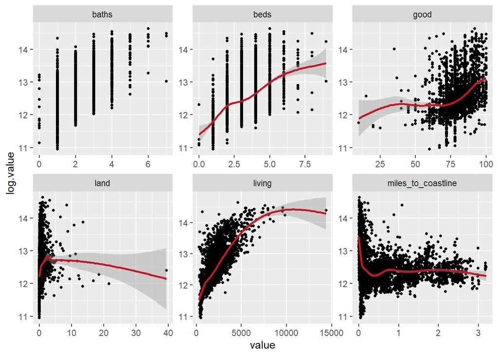

```r
ggplot(dd1 %>%
         filter(style != 'Mobile Home'),
       aes(x = value,
           y = log.value)) +
  geom_jitter(size = 1) +
  geom_smooth(linewidth = 1,
              color = pubred) +
  facet_wrap(~name,
             scales = 'free')
```

Observations from the above plot (you could also use observations we made in class):

- `beds`, `baths`, `living`, `miles_to_coastline` don’t appear to have a linear relationship.
- It’s unclear if land has a linear relationship. But that should be log transformed given the distribution is so right-skewed. Then we can investigate if it’s linear.
- `living` should be log transformed (from figure about or pset03)
- `good` may or may not be linear, though it’s decently linear except for the very small values

Let’s transform our data

```r
d = d %>%
  mutate(## Group some categories with low observations together
         beds  = ifelse(beds  > 6, 6, beds),
         baths = ifelse(baths > 4, 4, baths),
         grade = ifelse(grade == 'D', 'C -', grade),

         ## convert some predictors to categorical
         beds  = as.character(beds),
         baths = as.character(baths),

         ## releveling to make results more interpretable
         ac    = relevel(factor(ac)   , 'None'),
         style = relevel(factor(style), 'Mobile Home'))
```

We’ll use log transforms for `living` and `miles_to_coastline`, like we did on pset03.

```r
lm1 = lm(log(value) ~ log(land+1) + log(living) +
           beds + baths + good +
           style + grade + ac +
           log(miles_to_coastline),
         data = d)
summary(lm1)
```

```
##
## Call:
## lm(formula = log(value) ~ log(land + 1) + log(living) + beds +
##     baths + good + style + grade + ac + log(miles_to_coastline),
##     data = d)
##
## Residuals:
##      Min       1Q   Median       3Q      Max
## -0.75290 -0.12501 -0.00931  0.09006  2.30300
##
## Coefficients:
##                           Estimate Std. Error t value Pr(>|t|)
## (Intercept)              7.9413870  0.1717745  46.231  < 2e-16 ***
## log(land + 1)            0.1663015  0.0119522  13.914  < 2e-16 ***
## log(living)              0.3261053  0.0168245  19.383  < 2e-16 ***
## beds1                   -0.0355465  0.1006177  -0.353 0.723892
## beds2                    0.0343057  0.1021261   0.336 0.736950
## beds3                    0.0165152  0.1024906   0.161 0.871991
## beds4                    0.0492702  0.1027605   0.479 0.631629
## beds5                    0.0569560  0.1038903   0.548 0.583558
## beds6                    0.1064099  0.1063531   1.001 0.317103
## baths1                  -0.2321745  0.0681637  -3.406 0.000664 ***
## baths2                  -0.2406910  0.0686795  -3.505 0.000462 ***
## baths3                  -0.2217810  0.0693839  -3.196 0.001400 **
## baths4                  -0.1684571  0.0718061  -2.346 0.019017 *
## good                     0.0049892  0.0004801  10.392  < 2e-16 ***
## styleBungalow            2.1041023  0.0317338  66.305  < 2e-16 ***
## styleCape Cod            2.1014822  0.0259259  81.057  < 2e-16 ***
## styleColonial            2.0999430  0.0271797  77.261  < 2e-16 ***
## styleCottage             1.6784069  0.0355985  47.148  < 2e-16 ***
## styleCustom              2.5161046  0.0335848  74.918  < 2e-16 ***
## styleOld Style           2.0920112  0.0261442  80.018  < 2e-16 ***
## styleRaised Ranch        2.0499361  0.0279868  73.247  < 2e-16 ***
## styleSplit-Level         2.0908397  0.0282694  73.961  < 2e-16 ***
## styleTudor               2.1204120  0.2229505   9.511  < 2e-16 ***
## gradeA +                 0.1110296  0.0482525   2.301 0.021434 *
## gradeA ++                0.0290852  0.0936817   0.310 0.756218
## gradeB                  -0.2807387  0.0260209 -10.789  < 2e-16 ***
## gradeB -                -0.3964317  0.0263405 -15.050  < 2e-16 ***
## gradeB +                -0.1035371  0.0272499  -3.800 0.000147 ***
## gradeC                  -0.6354405  0.0285769 -22.236  < 2e-16 ***
## gradeC -                -0.6250575  0.0388459 -16.091  < 2e-16 ***
## gradeC +                -0.5218942  0.0273375 -19.091  < 2e-16 ***
## acCentral                0.0377210  0.0079047   4.772 1.88e-06 ***
## acHeat Pump             -0.0094508  0.0218503  -0.433 0.665380
## acPartial AC             0.0196550  0.0193915   1.014 0.310832
## acUnit/AC                0.1739736  0.1110517   1.567 0.117275
## log(miles_to_coastline) -0.1230848  0.0029816 -41.281  < 2e-16 ***
## ---
## Signif. codes:  0 '***' 0.001 '**' 0.01 '*' 0.05 '.' 0.1 ' ' 1
##
## Residual standard error: 0.2211 on 4753 degrees of freedom
##   (4 observations deleted due to missingness)
## Multiple R-squared:  0.9034, Adjusted R-squared:  0.9027
## F-statistic:  1270 on 35 and 4753 DF,  p-value: < 2.2e-16
```

2. I did some of this above. Let’s plot the residuals.

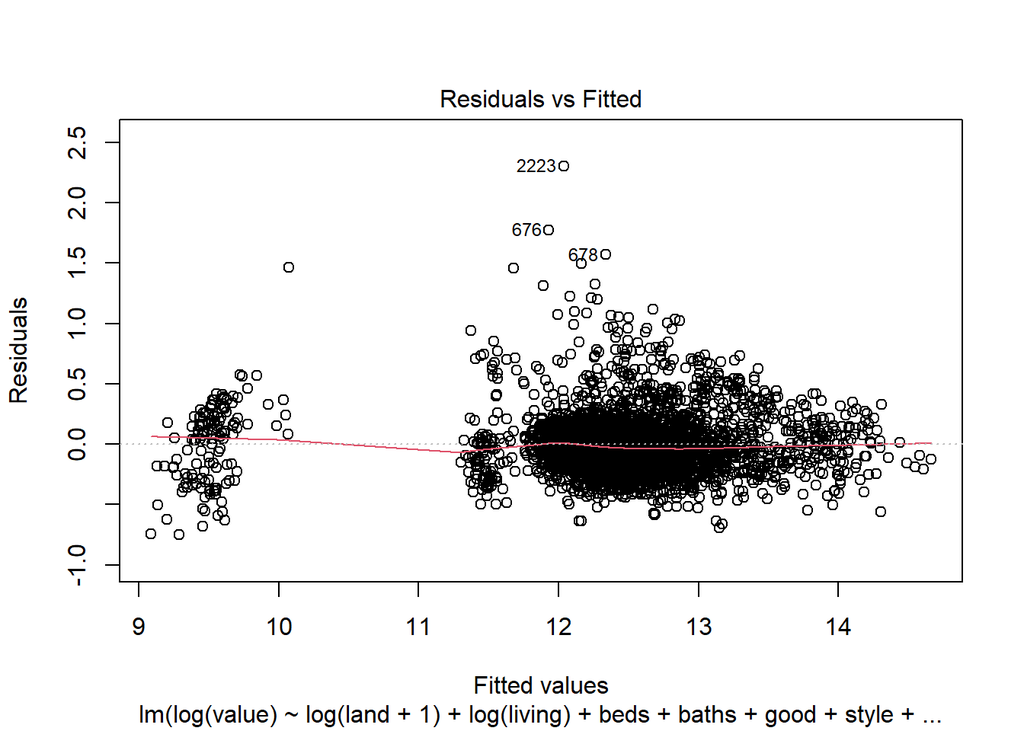

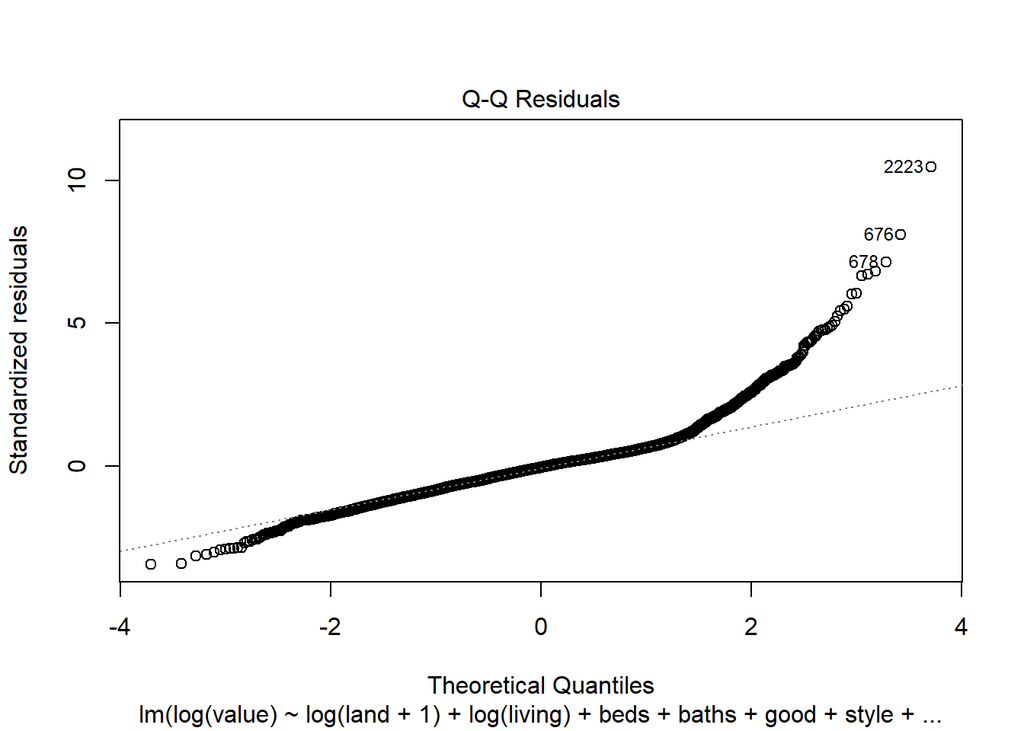

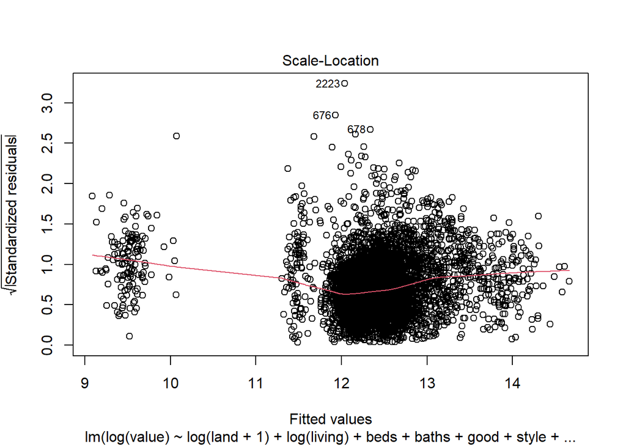

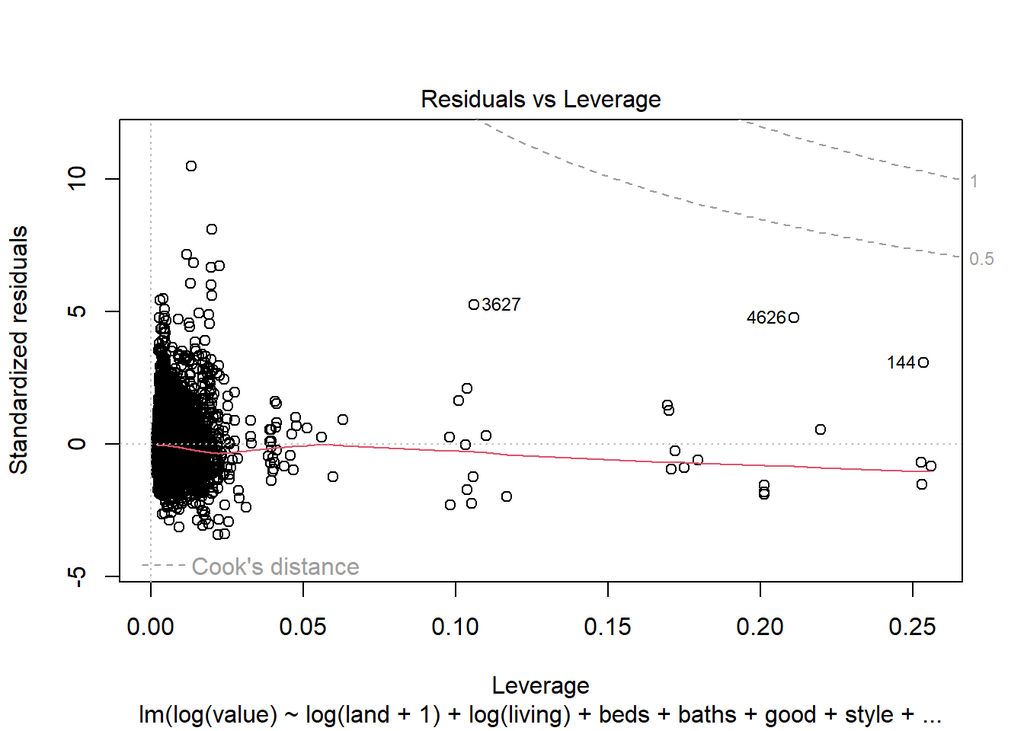

```r
plot(lm1)
```

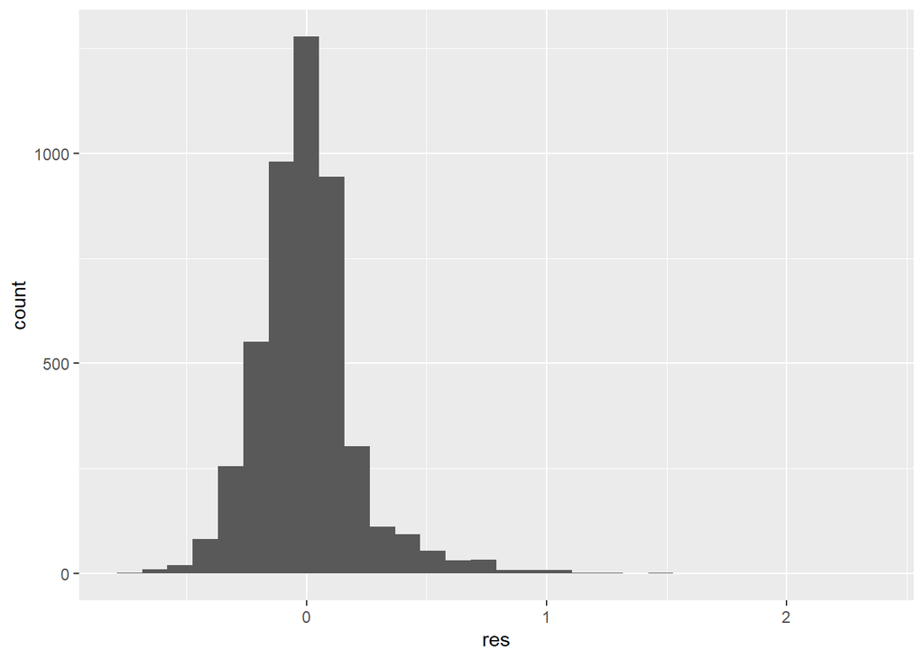

```r
d$lm1 = predict(lm1, newdata=d)
d$res = log(d$value) - d$lm1
ggplot(d,
       aes(x = res)) +
  geom_histogram()
```

Residuals are close to normal, but there’s a big right tail (can also be seen in the `plot(lm1)` output above). Other plots looks decent-ish, no other assumptions violated in a major way.